# Bayesian Generalized Nonlinear Models (BGNLM) for SINDy

**Bayesian Generalized Nonlinear Models (BGNLM)** offer a novel, flexible approach to solving Sparse Identification of Nonlinear Dynamics (SINDy) problems. Unlike traditional methods that rely on predefined libraries of candidate functions, BGNLM leverages probabilistic modeling and spike-and-slab priors to automatically discover relevant nonlinearities while providing robust uncertainty quantification.

## Highlights

- **Flexible Modeling**: No need for predefined basis functions.
- **Uncertainty Quantification**: Probabilistic framework enables robust exploration of model spaces.
- **Applications**: Successfully applied to various linear and nonlinear 3D systems, including Lorenz and hybrid Rössler-Lorenz systems.

## Key Features

1. Automatic discovery of nonlinear features without predefined libraries.
2. Bayesian inference using genetically modified mode jumping MCMC (GMJMCMC).
3. Quantification of uncertainty in selected models and predictions.

## Framework Overview

We model ordinary differential equations (ODEs) in the form:
$$\dot{\boldsymbol{x}}(t) =
\boldsymbol{f}(\boldsymbol{x}(t)),$$
with BGNLM providing sparse, interpretable solutions: $f_j(\boldsymbol{x}_i)=\sum_{k=1}^{q}\gamma_{jk}\beta_{jk}g_k(\boldsymbol{x}_i),$ where: - $g_k(\boldsymbol{x})$: Nonlinear features. - $\gamma_{jk}$: Binary inclusion indicators. - $\beta_{jk}$: Coefficients estimated via Bayesian inference.

## Applications

1. **Linear 3D System**
2. **Lorenz System**
3. **Rössler-Lorenz Hybrid System**

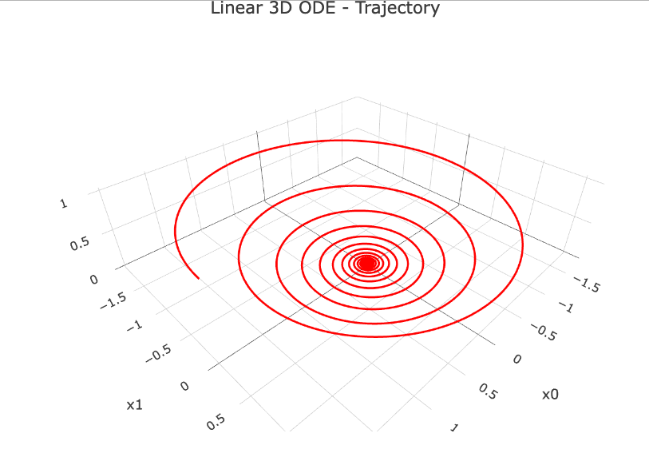

**Linear 3D System**

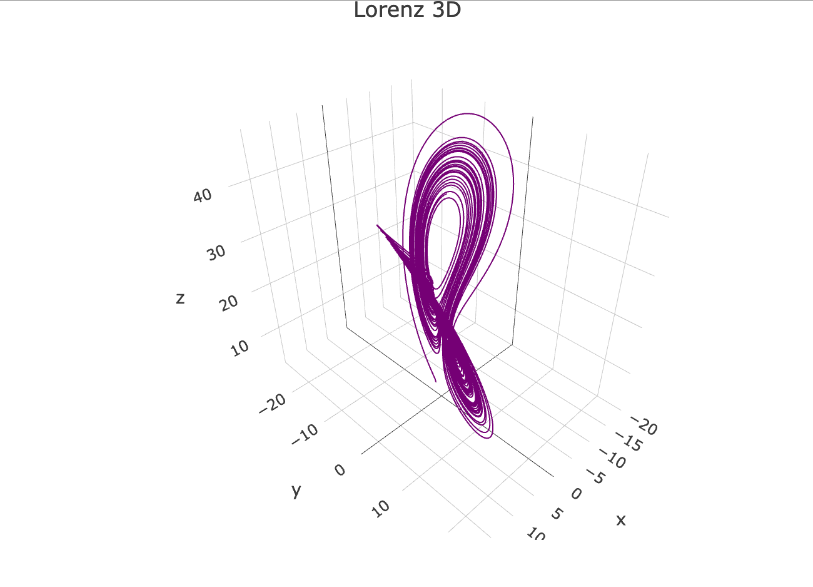

**Lorenz System**

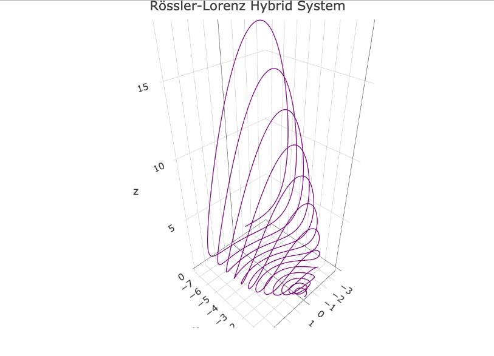

**Rössler-Lorenz Hybrid System**

For each system, we: - Simulated trajectories under varying noise levels. - Evaluated models on training, in-sample, and out-of-sample datasets. - Assessed performance with Power, FDR, and $R^2$.

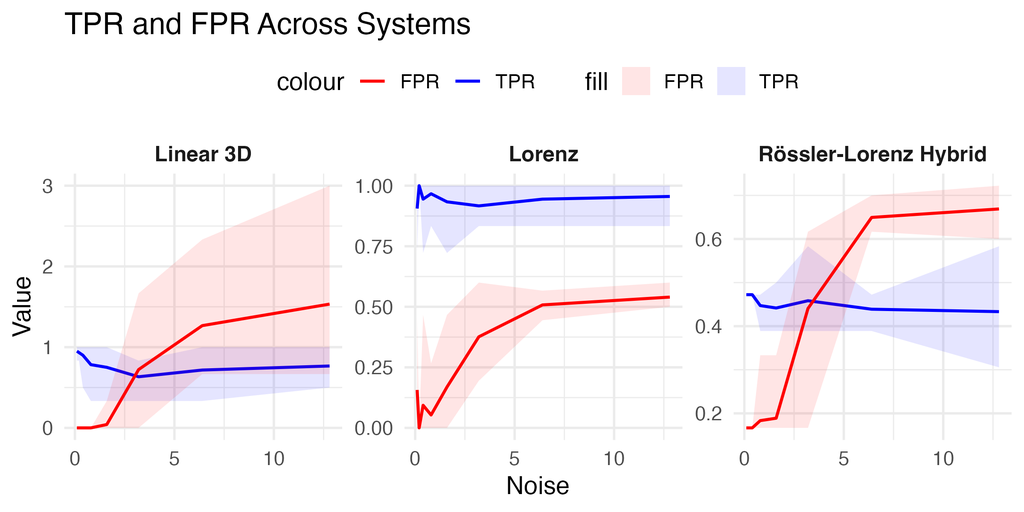

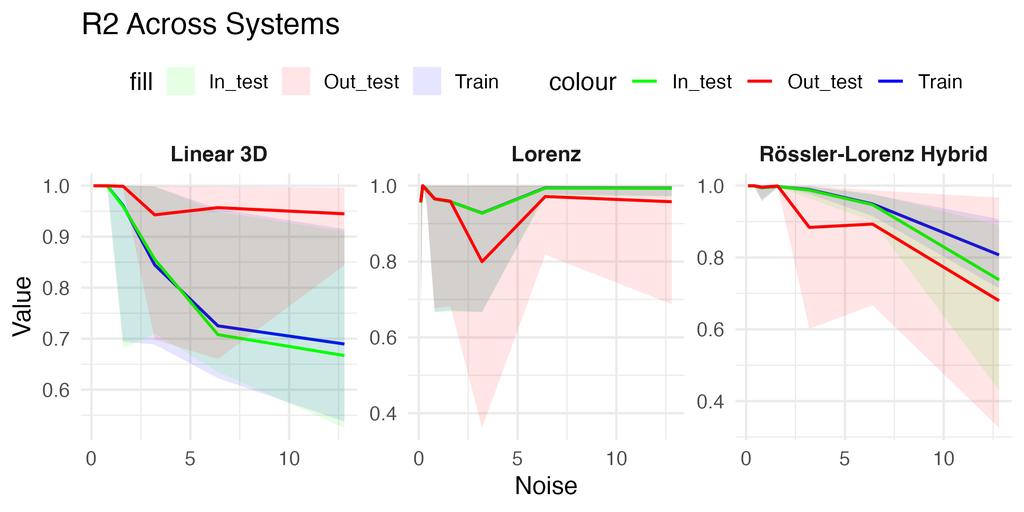

**R^2 curves**

## Future Work

- Explore signal-to-noise ratio thresholds for system identifiability.
- Extend to real-world dynamic systems.

## Implementation

The full implementation and datasets are available in the repo.

## References

- Brunton, S. L., Proctor, J. L., & Kutz, J. N. (2016). Discovering governing equations from data.
- Hirsh et al. (2022). Bayesian approaches to SINDy.
- Hubin et al. (2021). Bayesian Generalized Nonlinear Models (BGNLM).

For questions or collaboration, reach out at aliaksandr.hubin@nmbu.no.